# Intro to R: Exercises

## Exercise 6: Objects part 1

*Learning, exploring and understanding objects in R. Remember everything in R is an object.*

1. Assigning objects. Type `rexp <- YOUR LEVEL OF R EXPERIENCE`(as a number between 1 and 5, eg. 3) into the console. This assigns the value of 3 to the object rexp. Note that this object has now been added to the environment pane.
2. Type `first <- “YOUR FIRST NAME”` into the console to assign your first name to the object first.
3. Repeat #2 with your last name, save it as `last`.
4. Add another section label comment line to your script: `# Object Definitions ####`
5. Copy your `first`and `last`object assignment commands from *History* into that section of your script.
6. Access a private object (not exported to your environment when package attached) from the package cranlogs and save it as `url`. Run `url <- cranlogs:::base_url`in the console.
7. Run 3 again but wrap the entire statement in parentheses: (*statement*). This will show what you are saving to *url* while it’s being saved.
8. *Examining* the features of objects using functions. Let’s try a few.
9. Type `print(rexp)` into the console. What is the output? Type `print(url)` into the console. What is the output? What does the`print()` function do?
10. Type `class(rexp)` into the console. What is the output? Type `class(url)` into the console. What is the output? What does the `class()`function do?
11. Type `str(rexp)` into the console. Type `str(url)` into the console. What are the outputs and what does the `str()`function do?
12. Type `typeof(rexp)` into the console. Type `typeof(url)` into the console. What are the outputs and what does the `typeof()` function do?
13. *Look* at all of the objects in the environment by typing `ls()` into the console. Have a look at the output and compare that to the environment pane.
14. *Delete* the object called *deleteme* using the `remove()` function. Try`help()`if needed. Check that it has been deleted by using ls() again.
15. *Nesting* functions as objects.Type `round(pi, sqrt(4))` into the console. Note the output. Now type `round(pi, digits = sqrt(4))`. Note the output. What is the object in these two functions? Why does `round(pi, sqrt(4))and round(pi, digits = sqrt(4))`return the same output?
16. Practice nesting functions as objects
1. Use two nested`paste()`functions to create an email address from <your first name>, <your last name>, and <@mail.com>
2. Use the `separator “.”` between <your first name> and <your last name>.
3. The output should look like:`“yourfirstname.yourlastname@mail.com”`
17. Save the result of #16 to the object `email`and copy that command from *History* into your script.

```r
#Exercise 6 Objects-Part1

#Assign objects
rexp <- 3
first <- "Bob"
last <- "Smith"
url <- cranlogs:::base_url  #This will show what you are saving to url

#Note the object's age, first and url have been added to the environment pane

#Examining features of objects using functions

print(rexp)
```

```
## [1] 3
```

```r
print(url)
```

```
## [1] "http://cranlogs.r-pkg.org/"
```

```r
#print() prints the value of the object supplied

class(rexp)
```

```
## [1] "numeric"
```

```r
class(url)
```

```
## [1] "character"
```

```r
#class() examines the features of objects and prints the type of object

str(rexp)
```

```
##  num 3
```

```r
str(url)
```

```
##  chr "http://cranlogs.r-pkg.org/"
```

```r
#str() displays the basic structure of the object

typeof(rexp)
```

```
## [1] "double"
```

```r
typeof(url)
```

```
## [1] "character"
```

```r
#typeof() displays the type of an object.
#Every R object has an underlying "type"
#The "type" determines the set of possible values for the object"
#See help() for the possible types and values
help(typeof)

#Look at all the objects in the environment
ls()
```

```
##  [1] "deleteme"     "first"        "last"         "libraries"    "rexp"
##  [6] "studentexp1"  "studentexp2"  "studentfirst" "studentlast"  "surveysheet"
## [11] "url"          "x"            "xm"
```

```r
#output should include: "deleteme", "first", "studentexp1", "Studentexp2","studentfirst", "studentlast", "surveysheet" and "url"

#Delete the object called "deleteme" using remove()
remove(deleteme)

#If need more information on remove() use help()
help(remove)

#Check that "deleteme" object has been deleted from the environment using ls()
ls()
```

```
##  [1] "first"        "last"         "libraries"    "rexp"         "studentexp1"
##  [6] "studentexp2"  "studentfirst" "studentlast"  "surveysheet"  "url"
## [11] "x"            "xm"
```

```r
#Nesting functions as objects
#Understanding what the object is
#Understanding the order R processes functions
round(pi, sqrt(4))
```

```
## [1] 3.14
```

```r
round(pi, digits = sqrt(4))
```

```
## [1] 3.14
```

```r
#The object in these two functions is sqrt(4)
#R processes the inner most functions first
#The sqrt(4) is processed and acts as a numeric object passed to the argument of round()
#The Digits argument is not required as R processes the function in the proper order and assumes the format round(x, digits =)

#Practice nesting functions as objects
#Use two nested paste() functions to create an email address
#Using <your first name>, <your last name>, and <@mail.com>
#And use the separator "." between your first and last name
paste(paste(first, last, sep = "."), "@mail.com", sep = "")
```

```
## [1] "Bob.Smith@mail.com"
```

```r
email <- paste(paste(first, last, sep = "."), "@mail.com", sep = "")

#Remember default for sep = is a space therefore need to define no space
```

## Exercise 7: Objects part 2 - Vectors

*Remember everything in R is an object…*

1. Examine two environment variables, `studentexp1` and `studentexp2`, using the `print()`, `class(),` and `typeof()` functions. Examine the outputs.
2. Apply the following functions to the vectors, `studentexp1` and `studentexp2`: `length()`, `max()`, `sum()`, `mean()`, and `is.na()`
3. Look at the outputs for each vector and compare them. What happens when `max()`, `sum()`, `mean()`, and `is.na()` are used on `studentexp2`? With the is.na() function, this is the first time we are seeing logical values as the output, what do they represent?
4. Look at the documentation for `max()` using `help()`and determine how to run `max()` on `studentexp2` that removes the NA values from the computation. Repeat for `sum()` and `mean()`.
5. Apply each function to `studentexpt2` with the argument that removes NA from the computation.

*Making vectors*

6. Let’s start by making vectors with the : operator. Type into your console `x <- 1:8`, hit Enter then type `x` into your console and hit enter. You have now made the vector `x`a series of numbers from 1 to 8.
7. Next make a vector with `runif()`. Type `y <- runif(5)`. Take a look at your environment pane. You have now made the vector `y` that is a series of five random numbers between 0 and 1 generated by `runif()`.
8. Now make vectors using the `c()` function. Type into the console `myvector1 <- c(1, 2, 3)`. Then type `myvector2 <- c(1, 2, "three")`.
9. Look at the type of `myvector1` and `myvector2`using `typeof()`.
10. Look at the documentation for `c()` to understand how it applies coercion and the hierarchy it uses.

*Explore vectors further*

11. Type `paste("Sample", LETTERS)` into the console. Have a look at the output. Note R has a few built-in datasets and constants, LETTERS is one of these.
12. Type the same command as above but include the argument `collapse = ", ".`Look at the output. How has the`collapse argument` changed the output?
13. `paste()` “Sample” to `LETTERS` as above but with `sep = "_"`
14. Make a vector called `Samples` from the script in step 14. Check the environment pane.
15. Check the`length()` of the `Samples`vector.
16. Use `sample()` to make a subset of 10 elements from `Samples`. Check the arguments with help/?.
17. Subset out the first through third elements of `Samples` using `[].`Hint: Google “Subsetting in R”

```r
#Exercise 7 Objects-Part2 Vectors

#Examine two environment variables "studentexp1" and "studentexp2"
#Remember everything in R is an object so variables are also objects
#Use paste(), class() and typeof() functions to examine the variables
print(studentexp1)
```

```
##  [1] 2 2 3 2 1 2 1 5 1 2 1 1 1 2 1 3 2 3
```

```r
class(studentexp1)
```

```
## [1] "numeric"
```

```r
typeof(studentexp1)
```

```
## [1] "double"
```

```r
print(studentexp2)
```

```
##  [1]  2  2 NA NA  1  2  1 NA  1  2  1  1  1  2  1 NA  2  3
```

```r
class(studentexp2)
```

```
## [1] "numeric"
```

```r
typeof(studentexp2)
```

```
## [1] "double"
```

```r
#Apply the following functions to the vectors studentexp1 and studentexp
#length(), max(), sum(), mean() and is.na()
length(studentexp1)
```

```
## [1] 18
```

```r
max(studentexp1)
```

```
## [1] 5
```

```r
sum(studentexp1)
```

```
## [1] 35
```

```r
mean(studentexp1)
```

```
## [1] 1.944444
```

```r
is.na(studentexp1)
```

```
##  [1] FALSE FALSE FALSE FALSE FALSE FALSE FALSE FALSE FALSE FALSE FALSE FALSE
## [13] FALSE FALSE FALSE FALSE FALSE FALSE
```

```r
length(studentexp2)
```

```
## [1] 18
```

```r
max(studentexp2)
```

```
## [1] NA
```

```r
sum(studentexp2)
```

```
## [1] NA
```

```r
mean(studentexp2)
```

```
## [1] NA
```

```r
is.na(studentexp2)
```

```
##  [1] FALSE FALSE  TRUE  TRUE FALSE FALSE FALSE  TRUE FALSE FALSE FALSE FALSE
## [13] FALSE FALSE FALSE  TRUE FALSE FALSE
```

```r
#Because studentexp2 contains NA values output of the numerical computations of max(), sum(), mean() is NA
#is.na() identifies which values are NA /  missing values
#is.na() returns a logical vector of the same length as its argument x
#is.na() returns TRUE for elements marked NA and FALSE otherwise
#This is why when applied to studentexp1 or studentexp2 the number of FALSE or TRUE values is 18

#Determine how to apply max(), sum() and mean() to studentexp2 where the NA vlaues are removed
#Use help documentation
help("max")
help("sum")
help("mean")

#For each function the argument na.rm = is neded to remove NA values from the computation
max(studentexp2, na.rm = TRUE)
```

```
## [1] 3
```

```r
sum(studentexp2, na.rm = TRUE)
```

```
## [1] 22
```

```r
mean(studentexp2, na.rm = TRUE)
```

```
## [1] 1.571429
```

```r
#Making vectors
#Make a vector using the operator :
x <- 1:8
x
```

```
## [1] 1 2 3 4 5 6 7 8
```

```r
#Make a vector using runif()
y <- runif(5)
y
```

```
## [1] 0.5703924 0.8952954 0.5172695 0.5731855 0.2975939
```

```r
#Make vectors using c()
myvector1 <- c(1, 2, 3)
myvector1
```

```
## [1] 1 2 3
```

```r
myvector2 <- c(1, 2, "Three")
myvector2
```

```
## [1] "1"     "2"     "Three"
```

```r
#Look at the type for each myvector1 and myvector2
typeof(myvector1)
```

```
## [1] "double"
```

```r
typeof(myvector2)
```

```
## [1] "character"
```

```r
#Look at the documentation for c()
help("c")

#Vectors must have elements of the same type
#c() function will coerce the elements to the same type
#The coercion uses a hierarchy
#Hierarchy is lower to higher types: NULL < logical < integer < double < character

#Explore vectors further
paste("Sample", LETTERS)
```

```
##  [1] "Sample A" "Sample B" "Sample C" "Sample D" "Sample E" "Sample F"
##  [7] "Sample G" "Sample H" "Sample I" "Sample J" "Sample K" "Sample L"
## [13] "Sample M" "Sample N" "Sample O" "Sample P" "Sample Q" "Sample R"
## [19] "Sample S" "Sample T" "Sample U" "Sample V" "Sample W" "Sample X"
## [25] "Sample Y" "Sample Z"
```

```r
#Add the argument collapse to the above paste()
paste("Sample", LETTERS, collapse = ", ")
```

```
## [1] "Sample A, Sample B, Sample C, Sample D, Sample E, Sample F, Sample G, Sample H, Sample I, Sample J, Sample K, Sample L, Sample M, Sample N, Sample O, Sample P, Sample Q, Sample R, Sample S, Sample T, Sample U, Sample V, Sample W, Sample X, Sample Y, Sample Z"
```

```r
#The collapse argument makes a string of the samples using a comma as a separator

#Make a vector called Samples using paste() "Sample", LETTERS and sep = "_" argument
Samples <- paste("Sample", LETTERS, sep = "_")
Samples #output is the vector Samples with elements "Sample_A" "Sample_B" "Sample_C"...
```

```
##  [1] "Sample_A" "Sample_B" "Sample_C" "Sample_D" "Sample_E" "Sample_F"
##  [7] "Sample_G" "Sample_H" "Sample_I" "Sample_J" "Sample_K" "Sample_L"
## [13] "Sample_M" "Sample_N" "Sample_O" "Sample_P" "Sample_Q" "Sample_R"
## [19] "Sample_S" "Sample_T" "Sample_U" "Sample_V" "Sample_W" "Sample_X"
## [25] "Sample_Y" "Sample_Z"
```

```r
#Check length of Samples vector
length(Samples)
```

```
## [1] 26
```

```r
#Use sample() function to a make a subset of 10 elements from Samples
sample(Samples, 10)
```

```
##  [1] "Sample_O" "Sample_M" "Sample_K" "Sample_N" "Sample_P" "Sample_E"
##  [7] "Sample_Z" "Sample_A" "Sample_J" "Sample_U"
```

```r
#Subset out the first through third elements of Samples using []
Samples[c(1:3)]
```

```
## [1] "Sample_A" "Sample_B" "Sample_C"
```

## Exercise 8: Dataframes and Tibbles

Dataframes and tibbles are two very similar ways of storing tabular data. Let’s explore the difference between the two:

1. Attach the `tibble`package.
2. Type `mtcars` into the console and hit *Enter* to view the ‘Motor Trend Car Road Tests’ dataframe. Note how the dataframe is presented in the console.
3. Type `as_tibble(mtcars)`into the console. Note how the tibble is presented in the console. How did the presentation differ between `mtcars` and `as_tibble(mtcars`)?

Now let’s take a look at the different ways to view information contained within a dataframe/tibble:

4. The **summary()** function gives you the basic statistics of each column such as the mean and median. Type `summary(mtcars)` to get the summary statistics of the dataset.
5. We’ve got a faked version of the registration/survey data for this course called `surveysheet` that was loaded with `env.RData`. Type `View(surveysheet)` to view the dataframe in a spreadsheet-style outside the console.
6. Take a glimpse at the dataframe by typing `glimpse(surveysheet)` into the console. The `glimpse()`function makes it possible to see every column’s type and size in a concise way.
7. Attach the visdat package
8. Type `vis_dat(surveysheet`) to explore the data types and missing values of the dataframe. What data types do you see (ex. chr, numeric, date) in the “Plots” tab? Is there any missing data (NA)?
9. Investigate the missing data by typing `vis_miss(surveysheet, cluster=T)`. The **vis_miss()** function provides the percentages of missing data for each column and in total. By setting cluster=T (TRUE) we are specifying that we would like the rows to be arranged by missingness.
   1. What percentage of people had no preference (Webex or in-class)?
   2. What percentage of the data is missing in total? In the `Timestamp_2` column?

```r
# Exercise 8 DataFrames and Tibbles

# Attach the tibble package
library(tibble)
```

```r
# Identify the difference between Dataframes and Tibbles

# Try viewing the dataset as a dataframe
mtcars
```

```
##                      mpg cyl  disp  hp drat    wt  qsec vs am gear carb
## Mazda RX4           21.0   6 160.0 110 3.90 2.620 16.46  0  1    4    4
## Mazda RX4 Wag       21.0   6 160.0 110 3.90 2.875 17.02  0  1    4    4
## Datsun 710          22.8   4 108.0  93 3.85 2.320 18.61  1  1    4    1
## Hornet 4 Drive      21.4   6 258.0 110 3.08 3.215 19.44  1  0    3    1
## Hornet Sportabout   18.7   8 360.0 175 3.15 3.440 17.02  0  0    3    2
## Valiant             18.1   6 225.0 105 2.76 3.460 20.22  1  0    3    1
## Duster 360          14.3   8 360.0 245 3.21 3.570 15.84  0  0    3    4
## Merc 240D           24.4   4 146.7  62 3.69 3.190 20.00  1  0    4    2
## Merc 230            22.8   4 140.8  95 3.92 3.150 22.90  1  0    4    2
## Merc 280            19.2   6 167.6 123 3.92 3.440 18.30  1  0    4    4
## Merc 280C           17.8   6 167.6 123 3.92 3.440 18.90  1  0    4    4
## Merc 450SE          16.4   8 275.8 180 3.07 4.070 17.40  0  0    3    3
## Merc 450SL          17.3   8 275.8 180 3.07 3.730 17.60  0  0    3    3
## Merc 450SLC         15.2   8 275.8 180 3.07 3.780 18.00  0  0    3    3
## Cadillac Fleetwood  10.4   8 472.0 205 2.93 5.250 17.98  0  0    3    4
## Lincoln Continental 10.4   8 460.0 215 3.00 5.424 17.82  0  0    3    4
## Chrysler Imperial   14.7   8 440.0 230 3.23 5.345 17.42  0  0    3    4
## Fiat 128            32.4   4  78.7  66 4.08 2.200 19.47  1  1    4    1
## Honda Civic         30.4   4  75.7  52 4.93 1.615 18.52  1  1    4    2
## Toyota Corolla      33.9   4  71.1  65 4.22 1.835 19.90  1  1    4    1
## Toyota Corona       21.5   4 120.1  97 3.70 2.465 20.01  1  0    3    1
## Dodge Challenger    15.5   8 318.0 150 2.76 3.520 16.87  0  0    3    2
## AMC Javelin         15.2   8 304.0 150 3.15 3.435 17.30  0  0    3    2
## Camaro Z28          13.3   8 350.0 245 3.73 3.840 15.41  0  0    3    4
## Pontiac Firebird    19.2   8 400.0 175 3.08 3.845 17.05  0  0    3    2
## Fiat X1-9           27.3   4  79.0  66 4.08 1.935 18.90  1  1    4    1
## Porsche 914-2       26.0   4 120.3  91 4.43 2.140 16.70  0  1    5    2
## Lotus Europa        30.4   4  95.1 113 3.77 1.513 16.90  1  1    5    2
## Ford Pantera L      15.8   8 351.0 264 4.22 3.170 14.50  0  1    5    4
## Ferrari Dino        19.7   6 145.0 175 3.62 2.770 15.50  0  1    5    6
## Maserati Bora       15.0   8 301.0 335 3.54 3.570 14.60  0  1    5    8
## Volvo 142E          21.4   4 121.0 109 4.11 2.780 18.60  1  1    4    2
```

```r
# The top line contains all the column names and the row names are listed down the left

# Try viewing the dataset as a tibble
as_tibble(mtcars)
```

```
## # A tibble: 32 x 11
##      mpg   cyl  disp    hp  drat    wt  qsec    vs    am  gear  carb
##    <dbl> <dbl> <dbl> <dbl> <dbl> <dbl> <dbl> <dbl> <dbl> <dbl> <dbl>
##  1  21       6  160    110  3.9   2.62  16.5     0     1     4     4
##  2  21       6  160    110  3.9   2.88  17.0     0     1     4     4
##  3  22.8     4  108     93  3.85  2.32  18.6     1     1     4     1
##  4  21.4     6  258    110  3.08  3.22  19.4     1     0     3     1
##  5  18.7     8  360    175  3.15  3.44  17.0     0     0     3     2
##  6  18.1     6  225    105  2.76  3.46  20.2     1     0     3     1
##  7  14.3     8  360    245  3.21  3.57  15.8     0     0     3     4
##  8  24.4     4  147.    62  3.69  3.19  20       1     0     4     2
##  9  22.8     4  141.    95  3.92  3.15  22.9     1     0     4     2
## 10  19.2     6  168.   123  3.92  3.44  18.3     1     0     4     4
## # … with 22 more rows
```

```r
# Tibbles only print the first 10 rows and also reports the type of variable of each column
# Example: all the columns in mtcars are dbl or double-precision vectors (numeric values with decimal points)
# The tibble method of consicely printing information in the console makes working with large datasets easier

# View the summary statistics
summary(mtcars)
```

```
##       mpg             cyl             disp             hp
##  Min.   :10.40   Min.   :4.000   Min.   : 71.1   Min.   : 52.0
##  1st Qu.:15.43   1st Qu.:4.000   1st Qu.:120.8   1st Qu.: 96.5
##  Median :19.20   Median :6.000   Median :196.3   Median :123.0
##  Mean   :20.09   Mean   :6.188   Mean   :230.7   Mean   :146.7
##  3rd Qu.:22.80   3rd Qu.:8.000   3rd Qu.:326.0   3rd Qu.:180.0
##  Max.   :33.90   Max.   :8.000   Max.   :472.0   Max.   :335.0
##       drat             wt             qsec             vs
##  Min.   :2.760   Min.   :1.513   Min.   :14.50   Min.   :0.0000
##  1st Qu.:3.080   1st Qu.:2.581   1st Qu.:16.89   1st Qu.:0.0000
##  Median :3.695   Median :3.325   Median :17.71   Median :0.0000
##  Mean   :3.597   Mean   :3.217   Mean   :17.85   Mean   :0.4375
##  3rd Qu.:3.920   3rd Qu.:3.610   3rd Qu.:18.90   3rd Qu.:1.0000
##  Max.   :4.930   Max.   :5.424   Max.   :22.90   Max.   :1.0000
##        am              gear            carb
##  Min.   :0.0000   Min.   :3.000   Min.   :1.000
##  1st Qu.:0.0000   1st Qu.:3.000   1st Qu.:2.000
##  Median :0.0000   Median :4.000   Median :2.000
##  Mean   :0.4062   Mean   :3.688   Mean   :2.812
##  3rd Qu.:1.0000   3rd Qu.:4.000   3rd Qu.:4.000
##  Max.   :1.0000   Max.   :5.000   Max.   :8.000
```

```r
# Use View() to look at the dataframe outside the console
#View(surveysheet)

# Use glimpse() to look at the dataframe. Notice how it like a transposed tibble.
glimpse(surveysheet)
```

```
## Observations: 41
## Variables: 9
## $ First_Name     <chr> "Allison", "Daniel", "Carlos", "Joshua", "Derek", "Jus…
## $ Last_Name      <chr> "Taylor", "Bowman", "al-Sharaf", "Jarvis", "Lewis", "F…
## $ Email          <chr> "Allison.Taylor@mail.com", "Daniel.Bowman@mail.com", "…
## $ Timestamp_1    <dttm> 2019-10-24 15:23:09, 2019-10-25 07:25:29, 2019-10-25 …
## $ R_Experience_1 <dbl> 2, 2, 3, 2, 1, 2, 1, 5, 1, 2, 1, 1, 1, 2, 1, 3, 2, 3, …
## $ Timestamp_2    <dttm> 2020-01-20 13:49:05, 2020-01-08 14:38:58, NA, 2020-01…
## $ R_Experience_2 <dbl> 3, 2, NA, 2, NA, NA, NA, NA, NA, NA, NA, 2, NA, NA, NA…
## $ Preference     <chr> "WebEx", "In-Class", NA, "In-Class", NA, NA, NA, NA, N…
## $ R_Experience   <dbl> 2.5, 2.0, 3.0, 2.0, 1.0, 2.0, 1.0, 5.0, 1.0, 2.0, 1.0,…
```

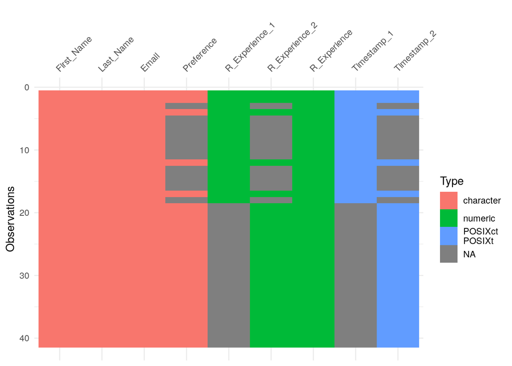

```r
# Attach the visdat package
library(visdat)

# Use vis_dat to explore the data types and missing values of the dataframe
vis_dat(surveysheet)
```

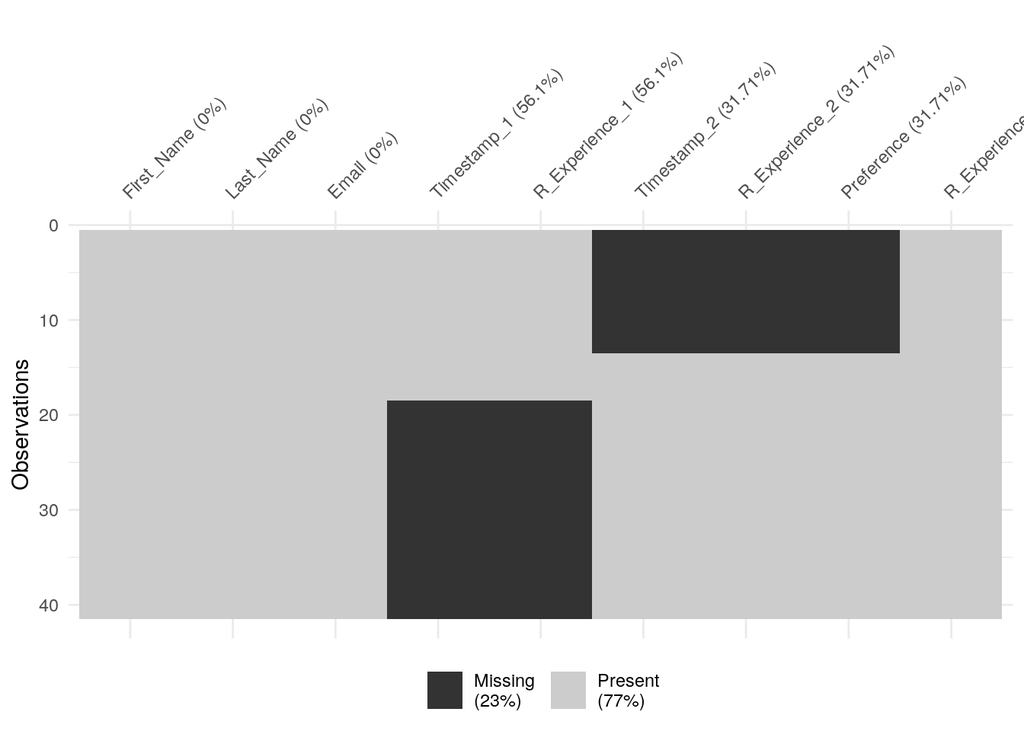

```r
# NA or missing data is in grey while the other types are color-coded

# Investigate the missing data
vis_miss(surveysheet, cluster=T)
```

```r
# What percentage of people had no preference (Webex or In-class)?
# 31.71%
# What percentage of the data is missing in total?
# 23%


# Extra:
# To view more information about the mtcars dataset you can type:
?mtcars
```

## Exercise 9: DPLYR Basics

*Remember dplyr verbs take the form: verb(tibble, arguments)*

1. Attach the `dplyr` package
2. `rename()` the `First_Name` column to `Given_Name`
   1. Remember that rename’s arguments take the form `newcol = oldcol`
   2. Did that change the object `surveysheet`?
3. Create these individual tibbles from surveysheet using `select()` *Remember to use ‘-’ to remove columns and name those you want to keep*
   1. `Email` and`R_Experience`
   2. `First_Name Last_Name Email`
   3. `Email` followed by `everything()` else
   4. Remove the following columns: `Timestamp_2, R_Experience_2, R_Experience`
   5. Only `First_Name` and `Last_Name` using ends_with()
   6. Everything except `First_Name` and `Last_Name` using `ends_with()`
4. `filter()` using
   1. `is.na()` on the `Timestamp_1` column
   2. logical expressions like
      1. `R_Experience` <= 2
      2. `R_Experience` above 3
      3. `Preference == "WebEx"`
      4. `Timestamp &lt; 2020-01-01`
      5. Both `Timestamp_1` and `Timestamp_2` not `NA`
5. `arrange()` based on
   1. `First_Name`
   2. `Last_Name`
   3. `Preference, Timestamp`
6. If we were to `mutate()` a new column based on `R_Experience` to show the person’s R experience as a percentage we would use the following:
   1. `mutate(surveysheet, R_Exp = R_Experience * 20)`
   2. How would we change that mutate call to express that new column as a decimal instead of percentage?
7. Create a new column with `mutate()`by pasting `First_Name` and `Last_Name` together. How would you use `snakecase::to_lower_upper_case()` on that new column?

```r
#Exercise 9 DPLYR Basics

#Remember dplyr verbs take the form: verb(tibble, arguments)

#Attach the dplyr package
library(dplyr)
```

```r
#rename() the First_Name column to Given_Name
rename(surveysheet, Given_Name = First_Name)
```

```
## # A tibble: 41 x 9
##    Given_Name Last_Name Email Timestamp_1         R_Experience_1
##    <chr>      <chr>     <chr> <dttm>                       <dbl>
##  1 Allison    Taylor    Alli… 2019-10-24 15:23:09              2
##  2 Daniel     Bowman    Dani… 2019-10-25 07:25:29              2
##  3 Carlos     al-Sharaf Carl… 2019-10-25 10:31:53              3
##  4 Joshua     Jarvis    Josh… 2019-10-25 12:12:34              2
##  5 Derek      Lewis     Dere… 2019-11-01 07:59:23              1
##  6 Justice    Fuentes   Just… 2019-11-01 15:15:11              2
##  7 Catherine  Shih      Cath… 2019-11-14 10:51:32              1
##  8 Taaliba    Lopez     Taal… 2019-11-15 11:53:57              5
##  9 Tomasa     Anderson  Toma… 2019-11-15 12:13:04              1
## 10 Masroora   Boone     Masr… 2019-11-15 12:45:51              2
## # … with 31 more rows, and 4 more variables: Timestamp_2 <dttm>,
## #   R_Experience_2 <dbl>, Preference <chr>, R_Experience <dbl>
```

```r
#This prints a tibble of surveysheet where now the first column is Given_Name

#Did this change the object surveysheet? Take a look at surveysheet
#View(surveysheet)
glimpse(surveysheet)
```

```
## Observations: 41
## Variables: 9
## $ First_Name     <chr> "Allison", "Daniel", "Carlos", "Joshua", "Derek", "Jus…
## $ Last_Name      <chr> "Taylor", "Bowman", "al-Sharaf", "Jarvis", "Lewis", "F…
## $ Email          <chr> "Allison.Taylor@mail.com", "Daniel.Bowman@mail.com", "…
## $ Timestamp_1    <dttm> 2019-10-24 15:23:09, 2019-10-25 07:25:29, 2019-10-25 …
## $ R_Experience_1 <dbl> 2, 2, 3, 2, 1, 2, 1, 5, 1, 2, 1, 1, 1, 2, 1, 3, 2, 3, …
## $ Timestamp_2    <dttm> 2020-01-20 13:49:05, 2020-01-08 14:38:58, NA, 2020-01…
## $ R_Experience_2 <dbl> 3, 2, NA, 2, NA, NA, NA, NA, NA, NA, NA, 2, NA, NA, NA…
## $ Preference     <chr> "WebEx", "In-Class", NA, "In-Class", NA, NA, NA, NA, N…
## $ R_Experience   <dbl> 2.5, 2.0, 3.0, 2.0, 1.0, 2.0, 1.0, 5.0, 1.0, 2.0, 1.0,…
```

```r
#First column is still First_Name in the object surveysheet
#Would need to re-write surveysheet to modify the object surveysheet
#To re-write: surveysheet <- rename(surveysheet, Given_Name = First_Name)

#Create individual tibbles from surveysheet using select()
#Remember to use - to remove columns and name what you want to keep

#Email and R_Experience
select(surveysheet, Email, R_Experience)
```

```
## # A tibble: 41 x 2
##    Email                     R_Experience
##    <chr>                            <dbl>
##  1 Allison.Taylor@mail.com            2.5
##  2 Daniel.Bowman@mail.com             2
##  3 Carlos.al-Sharaf@mail.com          3
##  4 Joshua.Jarvis@mail.com             2
##  5 Derek.Lewis@mail.com               1
##  6 Justice.Fuentes@mail.com           2
##  7 Catherine.Shih@mail.com            1
##  8 Taaliba.Lopez@mail.com             5
##  9 Tomasa.Anderson@mail.com           1
## 10 Masroora.Boone@mail.com            2
## # … with 31 more rows
```

```r
#First_Name Last_Name Email
select(surveysheet, 1:3)
```

```
## # A tibble: 41 x 3
##    First_Name Last_Name Email
##    <chr>      <chr>     <chr>
##  1 Allison    Taylor    Allison.Taylor@mail.com
##  2 Daniel     Bowman    Daniel.Bowman@mail.com
##  3 Carlos     al-Sharaf Carlos.al-Sharaf@mail.com
##  4 Joshua     Jarvis    Joshua.Jarvis@mail.com
##  5 Derek      Lewis     Derek.Lewis@mail.com
##  6 Justice    Fuentes   Justice.Fuentes@mail.com
##  7 Catherine  Shih      Catherine.Shih@mail.com
##  8 Taaliba    Lopez     Taaliba.Lopez@mail.com
##  9 Tomasa     Anderson  Tomasa.Anderson@mail.com
## 10 Masroora   Boone     Masroora.Boone@mail.com
## # … with 31 more rows
```

```r
#Email followed by everything() else
select(surveysheet, Email, everything())
```

```
## # A tibble: 41 x 9
##    Email First_Name Last_Name Timestamp_1         R_Experience_1
##    <chr> <chr>      <chr>     <dttm>                       <dbl>
##  1 Alli… Allison    Taylor    2019-10-24 15:23:09              2
##  2 Dani… Daniel     Bowman    2019-10-25 07:25:29              2
##  3 Carl… Carlos     al-Sharaf 2019-10-25 10:31:53              3
##  4 Josh… Joshua     Jarvis    2019-10-25 12:12:34              2
##  5 Dere… Derek      Lewis     2019-11-01 07:59:23              1
##  6 Just… Justice    Fuentes   2019-11-01 15:15:11              2
##  7 Cath… Catherine  Shih      2019-11-14 10:51:32              1
##  8 Taal… Taaliba    Lopez     2019-11-15 11:53:57              5
##  9 Toma… Tomasa     Anderson  2019-11-15 12:13:04              1
## 10 Masr… Masroora   Boone     2019-11-15 12:45:51              2
## # … with 31 more rows, and 4 more variables: Timestamp_2 <dttm>,
## #   R_Experience_2 <dbl>, Preference <chr>, R_Experience <dbl>
```

```r
#Remove the following columns:
#Timestamp_2
#R_Experience_2
#R_Experience
select(surveysheet, -Timestamp_2, -R_Experience_2, -R_Experience)
```

```
## # A tibble: 41 x 6
##    First_Name Last_Name Email      Timestamp_1         R_Experience_1 Preference
##    <chr>      <chr>     <chr>      <dttm>                       <dbl> <chr>
##  1 Allison    Taylor    Allison.T… 2019-10-24 15:23:09              2 WebEx
##  2 Daniel     Bowman    Daniel.Bo… 2019-10-25 07:25:29              2 In-Class
##  3 Carlos     al-Sharaf Carlos.al… 2019-10-25 10:31:53              3 <NA>
##  4 Joshua     Jarvis    Joshua.Ja… 2019-10-25 12:12:34              2 In-Class
##  5 Derek      Lewis     Derek.Lew… 2019-11-01 07:59:23              1 <NA>
##  6 Justice    Fuentes   Justice.F… 2019-11-01 15:15:11              2 <NA>
##  7 Catherine  Shih      Catherine… 2019-11-14 10:51:32              1 <NA>
##  8 Taaliba    Lopez     Taaliba.L… 2019-11-15 11:53:57              5 <NA>
##  9 Tomasa     Anderson  Tomasa.An… 2019-11-15 12:13:04              1 <NA>
## 10 Masroora   Boone     Masroora.… 2019-11-15 12:45:51              2 <NA>
## # … with 31 more rows
```

```r
#Show only First_Name  and Last_Name using ends_with()
select(surveysheet, ends_with("Name"))
```

```
## # A tibble: 41 x 2
##    First_Name Last_Name
##    <chr>      <chr>
##  1 Allison    Taylor
##  2 Daniel     Bowman
##  3 Carlos     al-Sharaf
##  4 Joshua     Jarvis
##  5 Derek      Lewis
##  6 Justice    Fuentes
##  7 Catherine  Shih
##  8 Taaliba    Lopez
##  9 Tomasa     Anderson
## 10 Masroora   Boone
## # … with 31 more rows
```

```r
#Everything except First_Name and Last_Name using ends_with()
select(surveysheet, -ends_with("Name"))
```

```
## # A tibble: 41 x 7
##    Email Timestamp_1         R_Experience_1 Timestamp_2         R_Experience_2
##    <chr> <dttm>                       <dbl> <dttm>                       <dbl>
##  1 Alli… 2019-10-24 15:23:09              2 2020-01-20 13:49:05              3
##  2 Dani… 2019-10-25 07:25:29              2 2020-01-08 14:38:58              2
##  3 Carl… 2019-10-25 10:31:53              3 NA                              NA
##  4 Josh… 2019-10-25 12:12:34              2 2020-01-15 09:53:19              2
##  5 Dere… 2019-11-01 07:59:23              1 NA                              NA
##  6 Just… 2019-11-01 15:15:11              2 NA                              NA
##  7 Cath… 2019-11-14 10:51:32              1 NA                              NA
##  8 Taal… 2019-11-15 11:53:57              5 NA                              NA
##  9 Toma… 2019-11-15 12:13:04              1 NA                              NA
## 10 Masr… 2019-11-15 12:45:51              2 NA                              NA
## # … with 31 more rows, and 2 more variables: Preference <chr>,
## #   R_Experience <dbl>
```

```r
#filter() using is.na() on the Timestamp_1 column
filter(surveysheet, is.na(Timestamp_1))
```

```
## # A tibble: 23 x 9
##    First_Name Last_Name Email Timestamp_1         R_Experience_1
##    <chr>      <chr>     <chr> <dttm>                       <dbl>
##  1 Schuyler   Lee       Schu… NA                              NA
##  2 Omari      Cordero   Omar… NA                              NA
##  3 Damon      Proctor   Damo… NA                              NA
##  4 Kaarim     Mustafa   Kaar… NA                              NA
##  5 Kent       Nubine    Kent… NA                              NA
##  6 Alyssa     Leal      Alys… NA                              NA
##  7 Emily      Guzman    Emil… NA                              NA
##  8 Demetrius  Newton    Deme… NA                              NA
##  9 Kasey      Cotton    Kase… NA                              NA
## 10 Mackenzie  Palmier   Mack… NA                              NA
## # … with 13 more rows, and 4 more variables: Timestamp_2 <dttm>,
## #   R_Experience_2 <dbl>, Preference <chr>, R_Experience <dbl>
```

```r
#filter() using the following logical expressions:
#R_Experience <=2
filter(surveysheet, R_Experience <= 2)
```

```
## # A tibble: 29 x 9
##    First_Name Last_Name Email Timestamp_1         R_Experience_1
##    <chr>      <chr>     <chr> <dttm>                       <dbl>
##  1 Daniel     Bowman    Dani… 2019-10-25 07:25:29              2
##  2 Joshua     Jarvis    Josh… 2019-10-25 12:12:34              2
##  3 Derek      Lewis     Dere… 2019-11-01 07:59:23              1
##  4 Justice    Fuentes   Just… 2019-11-01 15:15:11              2
##  5 Catherine  Shih      Cath… 2019-11-14 10:51:32              1
##  6 Tomasa     Anderson  Toma… 2019-11-15 12:13:04              1
##  7 Masroora   Boone     Masr… 2019-11-15 12:45:51              2
##  8 Brittany   Lowe      Brit… 2019-11-15 12:47:22              1
##  9 Tyler      Chism     Tyle… 2019-11-21 13:58:41              1
## 10 Jonah      Rondeau   Jona… 2019-11-21 14:29:18              1
## # … with 19 more rows, and 4 more variables: Timestamp_2 <dttm>,
## #   R_Experience_2 <dbl>, Preference <chr>, R_Experience <dbl>
```

```r
#R_Experience above 3
filter(surveysheet, R_Experience > 3) #Try this again by wrapping it in glimpse()
```

```
## # A tibble: 5 x 9
##   First_Name Last_Name Email Timestamp_1         R_Experience_1
##   <chr>      <chr>     <chr> <dttm>                       <dbl>
## 1 Taaliba    Lopez     Taal… 2019-11-15 11:53:57              5
## 2 Alyssa     Leal      Alys… NA                              NA
## 3 Demetrius  Newton    Deme… NA                              NA
## 4 Devon      Sanders   Devo… NA                              NA
## 5 Trevaughn  Casias    Trev… NA                              NA
## # … with 4 more variables: Timestamp_2 <dttm>, R_Experience_2 <dbl>,
## #   Preference <chr>, R_Experience <dbl>
```

```r
#Wrapping in glimpse() allows you to view the R_Experience filtered column

#Preference == "WebEx"
filter(surveysheet, Preference == "WebEx")
```

```
## # A tibble: 17 x 9
##    First_Name Last_Name Email Timestamp_1         R_Experience_1
##    <chr>      <chr>     <chr> <dttm>                       <dbl>
##  1 Allison    Taylor    Alli… 2019-10-24 15:23:09              2
##  2 Omari      Cordero   Omar… NA                              NA
##  3 Damon      Proctor   Damo… NA                              NA
##  4 Kent       Nubine    Kent… NA                              NA
##  5 Emily      Guzman    Emil… NA                              NA
##  6 Demetrius  Newton    Deme… NA                              NA
##  7 Kasey      Cotton    Kase… NA                              NA
##  8 Mackenzie  Palmier   Mack… NA                              NA
##  9 Jui-Chun   Taylor    Jui-… NA                              NA
## 10 Khaalid    Yarangsy  Khaa… NA                              NA
## 11 Jashinda   Liu       Jash… NA                              NA
## 12 Alex       Garnier   Alex… NA                              NA
## 13 Devin      Vela      Devi… NA                              NA
## 14 Jameela    Amato     Jame… NA                              NA
## 15 Trevaughn  Casias    Trev… NA                              NA
## 16 Nakheel    Hobbs     Nakh… NA                              NA
## 17 Douglas    al-Salem  Doug… NA                              NA
## # … with 4 more variables: Timestamp_2 <dttm>, R_Experience_2 <dbl>,
## #   Preference <chr>, R_Experience <dbl>
```

```r
glimpse(filter(surveysheet, Preference == "WebEx"))
```

```
## Observations: 17
## Variables: 9
## $ First_Name     <chr> "Allison", "Omari", "Damon", "Kent", "Emily", "Demetri…
## $ Last_Name      <chr> "Taylor", "Cordero", "Proctor", "Nubine", "Guzman", "N…
## $ Email          <chr> "Allison.Taylor@mail.com", "Omari.Cordero@mail.com", "…
## $ Timestamp_1    <dttm> 2019-10-24 15:23:09, NA, NA, NA, NA, NA, NA, NA, NA, …
## $ R_Experience_1 <dbl> 2, NA, NA, NA, NA, NA, NA, NA, NA, NA, NA, NA, NA, NA,…
## $ Timestamp_2    <dttm> 2020-01-20 13:49:05, 2020-01-10 17:21:47, 2020-01-14 …
## $ R_Experience_2 <dbl> 3, 2, 2, 1, 2, 4, 2, 3, 1, 1, 1, 2, 2, 1, 4, 1, 3
## $ Preference     <chr> "WebEx", "WebEx", "WebEx", "WebEx", "WebEx", "WebEx", …
## $ R_Experience   <dbl> 2.5, 2.0, 2.0, 1.0, 2.0, 4.0, 2.0, 3.0, 1.0, 1.0, 1.0,…
```

```r
#Timestamp < 2020-01-01
filter(surveysheet, Timestamp_1 < "2020-01-01")
```

```
## # A tibble: 17 x 9
##    First_Name Last_Name Email Timestamp_1         R_Experience_1
##    <chr>      <chr>     <chr> <dttm>                       <dbl>
##  1 Allison    Taylor    Alli… 2019-10-24 15:23:09              2
##  2 Daniel     Bowman    Dani… 2019-10-25 07:25:29              2
##  3 Carlos     al-Sharaf Carl… 2019-10-25 10:31:53              3
##  4 Joshua     Jarvis    Josh… 2019-10-25 12:12:34              2
##  5 Derek      Lewis     Dere… 2019-11-01 07:59:23              1
##  6 Justice    Fuentes   Just… 2019-11-01 15:15:11              2
##  7 Catherine  Shih      Cath… 2019-11-14 10:51:32              1
##  8 Taaliba    Lopez     Taal… 2019-11-15 11:53:57              5
##  9 Tomasa     Anderson  Toma… 2019-11-15 12:13:04              1
## 10 Masroora   Boone     Masr… 2019-11-15 12:45:51              2
## 11 Brittany   Lowe      Brit… 2019-11-15 12:47:22              1
## 12 Tyler      Chism     Tyle… 2019-11-21 13:58:41              1
## 13 Jonah      Rondeau   Jona… 2019-11-21 14:29:18              1
## 14 Mudrika    Watkins   Mudr… 2019-11-28 12:11:23              2
## 15 Aamir      Camacho   Aami… 2019-11-28 12:11:48              1
## 16 Lawrence   Pronteau  Lawr… 2019-11-29 09:29:50              3
## 17 Samir      Hutcheson Sami… 2019-12-05 13:13:13              2
## # … with 4 more variables: Timestamp_2 <dttm>, R_Experience_2 <dbl>,
## #   Preference <chr>, R_Experience <dbl>
```

```r
#Both Timestamp_1 and Timestamp_2, which are not NA
filter(surveysheet, !is.na(Timestamp_1) &!is.na(Timestamp_2))
```

```
## # A tibble: 5 x 9
##   First_Name Last_Name Email Timestamp_1         R_Experience_1
##   <chr>      <chr>     <chr> <dttm>                       <dbl>
## 1 Allison    Taylor    Alli… 2019-10-24 15:23:09              2
## 2 Daniel     Bowman    Dani… 2019-10-25 07:25:29              2
## 3 Joshua     Jarvis    Josh… 2019-10-25 12:12:34              2
## 4 Tyler      Chism     Tyle… 2019-11-21 13:58:41              1
## 5 Samir      Hutcheson Sami… 2019-12-05 13:13:13              2
## # … with 4 more variables: Timestamp_2 <dttm>, R_Experience_2 <dbl>,
## #   Preference <chr>, R_Experience <dbl>
```

```r
#Note: ! operator indicates Not

#arrange() based on:
#First_Name
arrange(surveysheet, First_Name)
```

```
## # A tibble: 41 x 9
##    First_Name Last_Name Email Timestamp_1         R_Experience_1
##    <chr>      <chr>     <chr> <dttm>                       <dbl>
##  1 Aamir      Camacho   Aami… 2019-11-28 12:11:48              1
##  2 Alex       Garnier   Alex… NA                              NA
##  3 Allison    Taylor    Alli… 2019-10-24 15:23:09              2
##  4 Alyssa     Leal      Alys… NA                              NA
##  5 Brandon    Hubbard   Bran… NA                              NA
##  6 Brittany   Lowe      Brit… 2019-11-15 12:47:22              1
##  7 Carlos     al-Sharaf Carl… 2019-10-25 10:31:53              3
##  8 Catherine  Shih      Cath… 2019-11-14 10:51:32              1
##  9 Damon      Proctor   Damo… NA                              NA
## 10 Daniel     Bowman    Dani… 2019-10-25 07:25:29              2
## # … with 31 more rows, and 4 more variables: Timestamp_2 <dttm>,
## #   R_Experience_2 <dbl>, Preference <chr>, R_Experience <dbl>
```

```r
#Last_Name
arrange(surveysheet, Last_Name)
```

```
## # A tibble: 41 x 9
##    First_Name Last_Name Email Timestamp_1         R_Experience_1
##    <chr>      <chr>     <chr> <dttm>                       <dbl>
##  1 Douglas    al-Salem  Doug… NA                              NA
##  2 Carlos     al-Sharaf Carl… 2019-10-25 10:31:53              3
##  3 Jameela    Amato     Jame… NA                              NA
##  4 Tomasa     Anderson  Toma… 2019-11-15 12:13:04              1
##  5 Masroora   Boone     Masr… 2019-11-15 12:45:51              2
##  6 Daniel     Bowman    Dani… 2019-10-25 07:25:29              2
##  7 Aamir      Camacho   Aami… 2019-11-28 12:11:48              1
##  8 Trevaughn  Casias    Trev… NA                              NA
##  9 Tyler      Chism     Tyle… 2019-11-21 13:58:41              1
## 10 Omari      Cordero   Omar… NA                              NA
## # … with 31 more rows, and 4 more variables: Timestamp_2 <dttm>,
## #   R_Experience_2 <dbl>, Preference <chr>, R_Experience <dbl>
```

```r
#Preference, Timestamp
arrange(surveysheet, Preference, Timestamp_1, Timestamp_2)
```

```
## # A tibble: 41 x 9
##    First_Name Last_Name Email Timestamp_1         R_Experience_1
##    <chr>      <chr>     <chr> <dttm>                       <dbl>
##  1 Daniel     Bowman    Dani… 2019-10-25 07:25:29              2
##  2 Joshua     Jarvis    Josh… 2019-10-25 12:12:34              2
##  3 Tyler      Chism     Tyle… 2019-11-21 13:58:41              1
##  4 Samir      Hutcheson Sami… 2019-12-05 13:13:13              2
##  5 Schuyler   Lee       Schu… NA                              NA
##  6 Kaarim     Mustafa   Kaar… NA                              NA
##  7 Alyssa     Leal      Alys… NA                              NA
##  8 Raadiya    Mercer    Raad… NA                              NA
##  9 Brandon    Hubbard   Bran… NA                              NA
## 10 Ya'eesh    White     Ya'e… NA                              NA
## # … with 31 more rows, and 4 more variables: Timestamp_2 <dttm>,
## #   R_Experience_2 <dbl>, Preference <chr>, R_Experience <dbl>
```

```r
#Using the mutate() function
#To create a new column based on R_Experience to show the experience as a percentage
mutate(surveysheet, R_Exp = R_Experience *20)
```

```
## # A tibble: 41 x 10
##    First_Name Last_Name Email Timestamp_1         R_Experience_1
##    <chr>      <chr>     <chr> <dttm>                       <dbl>
##  1 Allison    Taylor    Alli… 2019-10-24 15:23:09              2
##  2 Daniel     Bowman    Dani… 2019-10-25 07:25:29              2
##  3 Carlos     al-Sharaf Carl… 2019-10-25 10:31:53              3
##  4 Joshua     Jarvis    Josh… 2019-10-25 12:12:34              2
##  5 Derek      Lewis     Dere… 2019-11-01 07:59:23              1
##  6 Justice    Fuentes   Just… 2019-11-01 15:15:11              2
##  7 Catherine  Shih      Cath… 2019-11-14 10:51:32              1
##  8 Taaliba    Lopez     Taal… 2019-11-15 11:53:57              5
##  9 Tomasa     Anderson  Toma… 2019-11-15 12:13:04              1
## 10 Masroora   Boone     Masr… 2019-11-15 12:45:51              2
## # … with 31 more rows, and 5 more variables: Timestamp_2 <dttm>,
## #   R_Experience_2 <dbl>, Preference <chr>, R_Experience <dbl>, R_Exp <dbl>
```

```r
#Change the mutate() call to express the new column as a decimal
mutate(surveysheet, R_Exp = R_Experience *.2)
```

```
## # A tibble: 41 x 10
##    First_Name Last_Name Email Timestamp_1         R_Experience_1
##    <chr>      <chr>     <chr> <dttm>                       <dbl>
##  1 Allison    Taylor    Alli… 2019-10-24 15:23:09              2
##  2 Daniel     Bowman    Dani… 2019-10-25 07:25:29              2
##  3 Carlos     al-Sharaf Carl… 2019-10-25 10:31:53              3
##  4 Joshua     Jarvis    Josh… 2019-10-25 12:12:34              2
##  5 Derek      Lewis     Dere… 2019-11-01 07:59:23              1
##  6 Justice    Fuentes   Just… 2019-11-01 15:15:11              2
##  7 Catherine  Shih      Cath… 2019-11-14 10:51:32              1
##  8 Taaliba    Lopez     Taal… 2019-11-15 11:53:57              5
##  9 Tomasa     Anderson  Toma… 2019-11-15 12:13:04              1
## 10 Masroora   Boone     Masr… 2019-11-15 12:45:51              2
## # … with 31 more rows, and 5 more variables: Timestamp_2 <dttm>,
## #   R_Experience_2 <dbl>, Preference <chr>, R_Experience <dbl>, R_Exp <dbl>
```

```r
#Create a new column with mutate() by pasting First_Name and Last_Name together
mutate(surveysheet, Name = paste(First_Name, Last_Name))
```

```
## # A tibble: 41 x 10
##    First_Name Last_Name Email Timestamp_1         R_Experience_1
##    <chr>      <chr>     <chr> <dttm>                       <dbl>
##  1 Allison    Taylor    Alli… 2019-10-24 15:23:09              2
##  2 Daniel     Bowman    Dani… 2019-10-25 07:25:29              2
##  3 Carlos     al-Sharaf Carl… 2019-10-25 10:31:53              3
##  4 Joshua     Jarvis    Josh… 2019-10-25 12:12:34              2
##  5 Derek      Lewis     Dere… 2019-11-01 07:59:23              1
##  6 Justice    Fuentes   Just… 2019-11-01 15:15:11              2
##  7 Catherine  Shih      Cath… 2019-11-14 10:51:32              1
##  8 Taaliba    Lopez     Taal… 2019-11-15 11:53:57              5
##  9 Tomasa     Anderson  Toma… 2019-11-15 12:13:04              1
## 10 Masroora   Boone     Masr… 2019-11-15 12:45:51              2
## # … with 31 more rows, and 5 more variables: Timestamp_2 <dttm>,
## #   R_Experience_2 <dbl>, Preference <chr>, R_Experience <dbl>, Name <chr>
```

```r
#How would you use snakecase::to_lower_upper_case() on that new column?
mutate(surveysheet,
       CombNames = snakecase::to_lower_upper_case(
                                                  paste(First_Name,
                                                        Last_Name))) %>%
                                                                      View
```

## Exercise 10: DPLYR and Magrittr Pipes

The pipe (`%>%`) operator is a very useful way of taking the output of one statement and making it the input of the next statement. It also makes complex code a lot easier to read and understand.

Keyboard shortcuts for the pipe operator:

- Windows/Linux: `CTRL + SHIFT + M`
- OSX: `CMD + SHIFT + M`
1. Create a new R Script called surveymod.R
   1. Add titles, then library, objects, and code sections (with # NAME ####)
2. In the library section attach the following packages
   1. `dplyr`
   2. `magrittr`
3. Create a new minimal list from `surveysheet`. Using `magrittr` pipes to connect `dplyr` verbs create a tibble that shows only the following:
   1. A renamed `Email` column to `Contact_Info, First_Name` column to `Given_Name`, and `Last_Name` column to `Surname.`
   2. Columns in order of `Contact_Info`, `Given_Name`, `Surname` then `everything` else
   3. Tibble arranged by first `Timestamp_1`
   4. Save that to the object `newsurvey`
4. Create a new row in that tibble using dplyr’s `add_row()` function
   1. Look at the help for `add_row()`
   2. Glimpse newsurvey to see what columns you need
      1. Include `Contact_Info`, `Given_Name`, `Surname, Preference,`and`R_Experience`
      2. Use either “In-Class” or “WebEx” for Preference and estimate your current R Experience with a number from 1-5
   3. Separate your column names with commas  
      Eg. `newsurvey %>% add_row(First_Name = first, Last_Name = …)`
   4. Pipe the result into `View()` and see your addition
5. Create an email list for Webex participants. Using `magrittr` pipes to connect `dplyr` verbs pull a vector of `Contact_Info` from your `newsurvey` tibble:
   1. Filter out the In-Class people using the `Preference` column and a logical expression to choose either the answers `WebEx` **OR** `NA`
   2. Use `pull()` to get a vector of emails from `Contact_Info`
   3. Use `paste()` to make that into an Outlook compatible list of emails by collapsing them together with a semi-colon and a space (hint: `collapse = "; "`). Remember that
   4. Bask in the glory that is your email list.

```r
#Excercise 10 DPLYR and Magrittr Pipes

#Create a new minimal list from surveysheet
#Use magrittr pipes to connect dplyr verbs
#Create a tibble that shows the following:

newsurvey <- surveysheet %>% #saves the tibble to the object newsurvey
  arrange(Timestamp_1) %>%   #arranges by column Timestamp_1
  dplyr::rename(Contact_Info = Email, #renames the columns
         Given_Name = First_Name,
         Surname = Last_Name) %>%
  select(Contact_Info,  # selects the order of the columns
         Given_Name,
         Surname,
         everything())

#Create a new row in the tibble using dplyr's new_row() function
#Glimpse newsurvey to see what columns you need
glimpse(newsurvey)
```

```
## Observations: 41
## Variables: 9
## $ Contact_Info   <chr> "Allison.Taylor@mail.com", "Daniel.Bowman@mail.com", "…
## $ Given_Name     <chr> "Allison", "Daniel", "Carlos", "Joshua", "Derek", "Jus…
## $ Surname        <chr> "Taylor", "Bowman", "al-Sharaf", "Jarvis", "Lewis", "F…
## $ Timestamp_1    <dttm> 2019-10-24 15:23:09, 2019-10-25 07:25:29, 2019-10-25 …
## $ R_Experience_1 <dbl> 2, 2, 3, 2, 1, 2, 1, 5, 1, 2, 1, 1, 1, 2, 1, 3, 2, 3, …
## $ Timestamp_2    <dttm> 2020-01-20 13:49:05, 2020-01-08 14:38:58, NA, 2020-01…
## $ R_Experience_2 <dbl> 3, 2, NA, 2, NA, NA, NA, NA, NA, NA, NA, 2, NA, NA, NA…
## $ Preference     <chr> "WebEx", "In-Class", NA, "In-Class", NA, NA, NA, NA, N…
## $ R_Experience   <dbl> 2.5, 2.0, 3.0, 2.0, 1.0, 2.0, 1.0, 5.0, 1.0, 2.0, 1.0,…
```

```r
newsurvey %>% add_row(Given_Name = first,
                      Surname = last,
                      Contact_Info = email,
                      Preference = "WebEx",
                      R_Experience = rexp) %>% View

#Create an email list for WebEx participants
#Using magritter pipes to connect dplyr verbs
#Pull a vector of Contact_Info from your newsurvey tibble:

newsurvey %>% filter(Preference == "WebEx" | is.na(Preference)) %>%
  pull(Contact_Info) %>%
  paste(collapse = "; ")
```

```
## [1] "Allison.Taylor@mail.com; Carlos.al-Sharaf@mail.com; Derek.Lewis@mail.com; Justice.Fuentes@mail.com; Catherine.Shih@mail.com; Taaliba.Lopez@mail.com; Tomasa.Anderson@mail.com; Masroora.Boone@mail.com; Brittany.Lowe@mail.com; Jonah.Rondeau@mail.com; Mudrika.Watkins@mail.com; Aamir.Camacho@mail…
```

```r
#Make the above an object called emaillist
emaillist <- newsurvey %>%
  filter(Preference == "WebEx" | is.na(Preference)) %>%
  pull(Contact_Info) %>%
  paste(collapse = "; ")
```

## Exercise 11: Readr, Magrittr, and DPLYR

1. Create a new R Script name blastmod.R
   1. Add titles, then library, objects, and code sections (with # NAME ####)
2. In the library section attach the following packages
   1. `dplyr`
   2. `magrittr`
   3. `Rentrez`
   4. `readr`
3. Read in the blast hit table (hittable) from your data folder using RStudio’s menu items *Import Dataset > From Text(readr).*
   1. Untick *First Row as Names*
   2. Assign it to the object `hittable` in your environment
4. Look at the history pane for the `read_csv()` function call that RStudio created. Copy that into your script.
5. Use `vis_dat()` to take a look at the table. Take note of what the column names are, we will be renaming them.
6. Rename the column names of hittable using pipes and dplyr to:

```r
 c("query", "subject", "pid", "alignment_length", "mismatches", "gap_opens", "q_start", "q_end", "s_start", "s_end", "evalue", "bit_score")
```

1. Use `setNames()`, a base R function.
2. Make sure to write the changes back to hittable with `<-`

The following steps (7-10) should all be part of one continuous function linked by pipes

7. Rearrange the query sequences by descending order of bit scores using:
   1. `group_by()` to split the data frame by query sequence
   2. `arrange()` to reorder the rows according to the order and `desc()` to sort based on descending bit scores
8. Continuing on from #6, pipe the top 5 best hits
   1. `top_n()` to select the top 5 rows
9. Add the following pipes after `top_n()` to add summaries of the sequences from NCBI as a column and to name the column as `title`

```r
        %>%
          mutate(title = {
            entrez_summary("nucleotide", subject) %>%
              extract_from_esummary("title")
          }) %>%
```

10. Select only the `query,subject,title,bit_score,evalue,pid` columns
    1. Use `select()`
11. Run that pipeline again and save to the object tophits
12. Take a look at `tophits`. What is the top bit score?
13. Write the tophits table and save it in your workshop2020/output folder using `write_tsv()`

```r
# Exercise 11 Readr, Magrittr and DPLYR


# Library Statements
# Install the "rentrez" package if needed
# install.packages("rentrez")
library(rentrez)
library(dplyr)
library(magrittr)
library(readr)
```

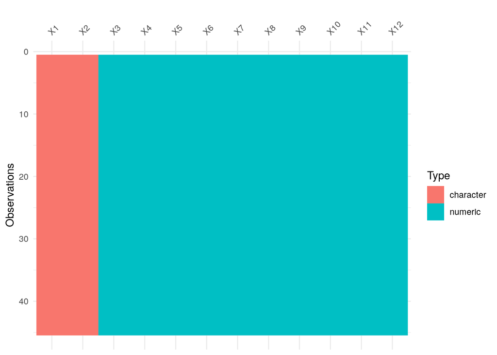

```r
# Objects ####

# Load the blast hit table (should be in your data folder)
hittable <- read_csv("~/repos/intro-R-course/data/hittable.csv",
                     col_names = FALSE)
# Examining the blast hit table
vis_dat(hittable)
```

```r
# Code ####
# Rename the columns, notice how the hittable must be rewritten to save the changes
hittable <- hittable %>%
  setNames(c("query", "subject", "pid", "alignment_length", "mismatches", "gap_opens", "q_start",
             "q_end", "s_start", "s_end", "evalue", "bit_score"))

# Rearrange the query sequences by descending order of bit scores, when you use the %>% you read from left to right
tophits <- hittable %>%
  group_by(query) %>%
  arrange(query, desc(bit_score)) %>%
  top_n(5) %>%
  mutate(title = {
    entrez_summary("nucleotide", subject) %>%
      extract_from_esummary("title")
  }) %>%
  select(query, subject, title, bit_score, evalue, pid)
# View tophits
# View(tophits)
# There are multiple sequences with the same bit score leading to more
# than 5 sequences being kept in tophits
# Top bit score is 654
```

```r
# Write the tophits table
write_tsv(tophits, "~/workshop2020/output/tophits.tsv")
```

*Wow. You made it! Good Job!*